# Introduction

**Total Sulfur Dioxide:**

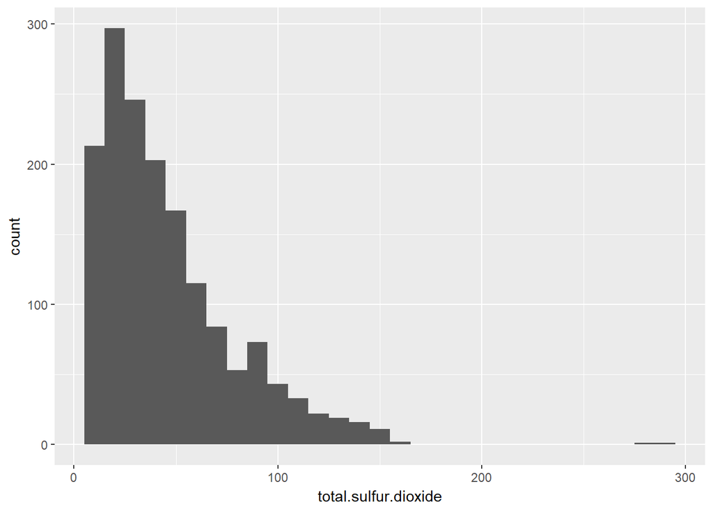

```
##    Min. 1st Qu.  Median    Mean 3rd Qu.    Max.
##    6.00   22.00   38.00   46.47   62.00  289.00
```

Total sulfur dioxide is the amount of free and bound forms of SO2 and is usually undetecable in wine, but when free form exceeds 50 ppm it is noticable in the tase and smell of the wine. It has a positive skew with a mean of 46.5.

**Density:**

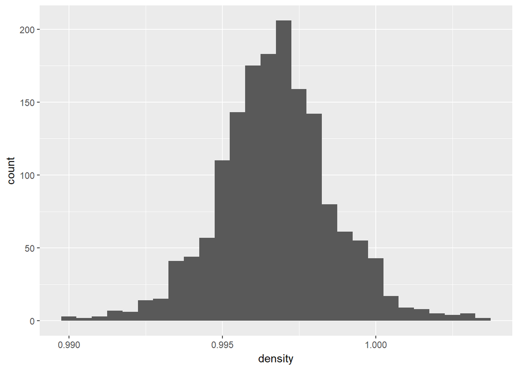

```
##    Min. 1st Qu.  Median    Mean 3rd Qu.    Max.
##  0.9901  0.9956  0.9968  0.9967  0.9978  1.0037
```

Wine has a density similar to that of water but may change based on the amount of residual sugar and alcohol. The density of the wines has a normal distribution with a mean of 0.99.

**Suphlates:**

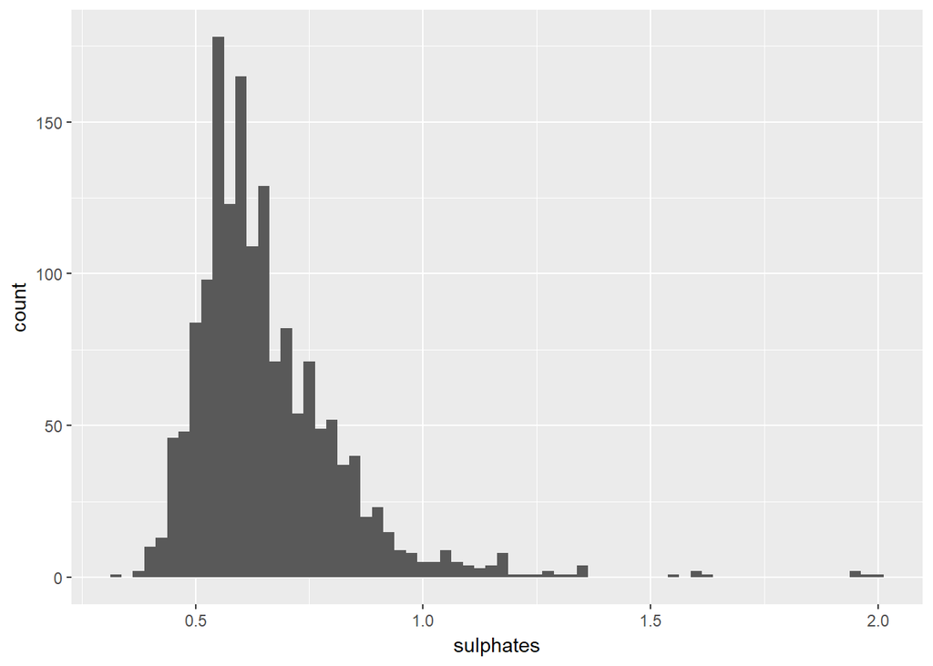

```
##    Min. 1st Qu.  Median    Mean 3rd Qu.    Max.
##  0.3300  0.5500  0.6200  0.6581  0.7300  2.0000
```

# Univariate Analysis

**Structure of the dataset**

- This data set consists of 11 chemical property variables and 1 quality variable with a total of 1599 observations.

**Other Observations**

Volatile acidity mean: 0.53

Alcohol mean: 10.42

Chloride mean: 0.09

**Main features of interest**

- The most telling variable is quality. However, every other variable plays into the outcome of the quality and so the most influentail variables are the ones that directly impact taste. Those variables include volatile acidity, citric acid, residual sugar, alcohol, and chloride.
- After examining the initial plots and seeing the distribution of the chemical properites, I am eager to find out just how much each one affects the quality of the wine and in what way.

**Adjustments**

- I also transformed the data by applying log10 to chloride and residual sugar to get a better visualiztion of the spread. I chose to use freqpoly for some of the normally distributed variables to show morre detail in the up and down ticks that could not be seen in a histogram.

# Bivariate Plots Section

Below is the volatile acidity for the best quality wines, those rated 7 or above.

**Volatile Acidity:**

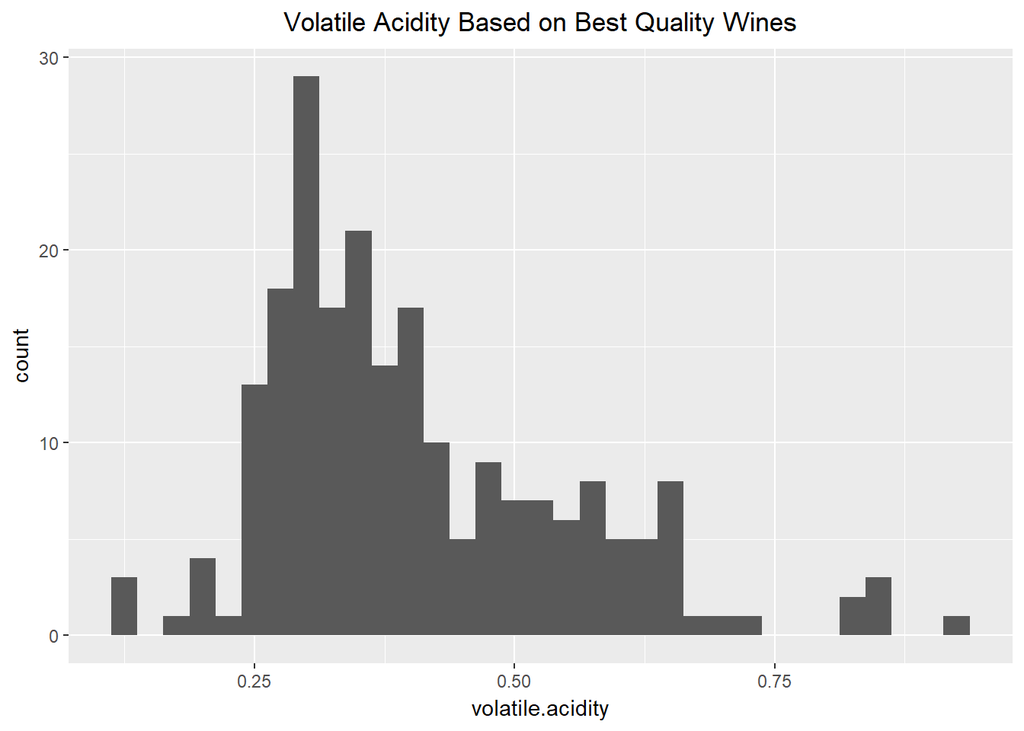

```
##    Min. 1st Qu.  Median    Mean 3rd Qu.    Max.
##  0.1200  0.3000  0.3700  0.4055  0.4900  0.9150
```

The overall max for volatile acidity is 1.6 and the minimum is 0.12. The lower volatile acidity levels were associated with better quality wine. THe max level for the best quality wines was 0.9 with a median of 0.37 and its minimum was equal to the minimum of the entire dataset.

Below is the volatile acidity levels of the worst quality wines, those rated 5 or below.

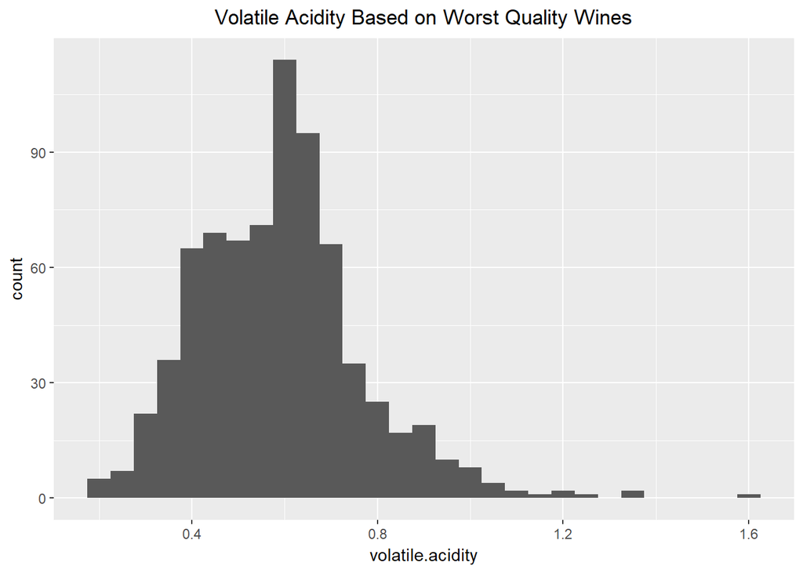

[output not shown]

On the other hand, the worst quality wines had the highest acidity levels. Its max was equal to that of the entire dataset, the median was double that of the best quality wines an its minimum was nearly double the minimum of the best quality wines.

**Correlation Diagram**

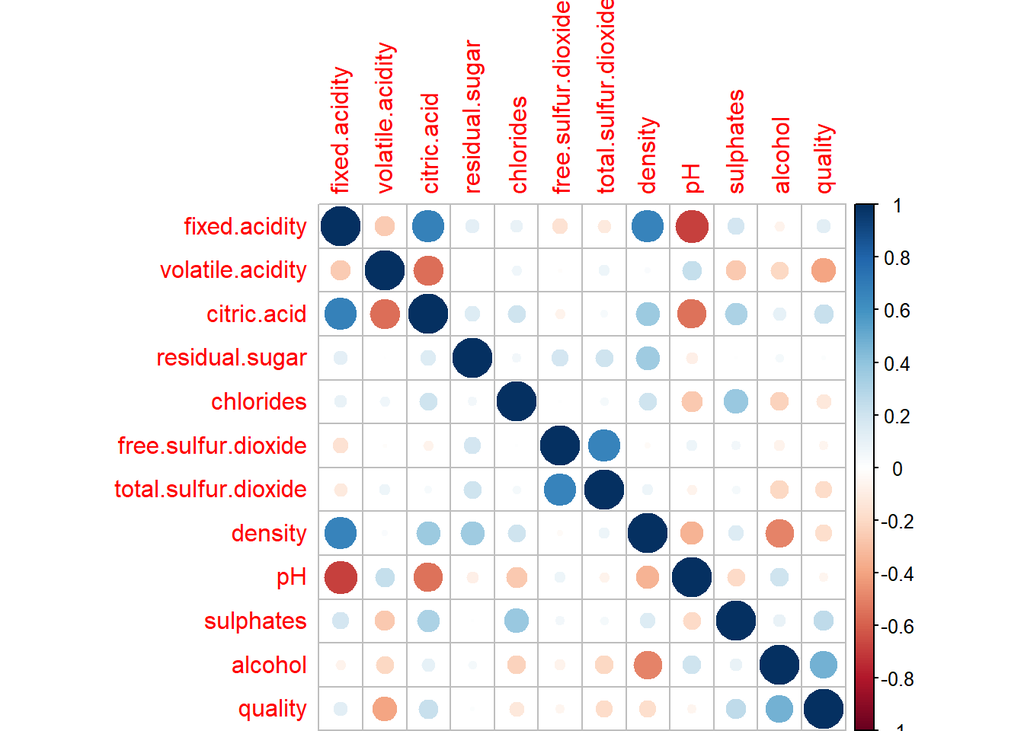

Above is the correlation plot that shows the level of correlation between each chemical property.

Below are scatterplots I created based on the strongest correlated variables according to the correlation diagram seen above. These will help visualize the relationship between the variables.

**Correlations:**

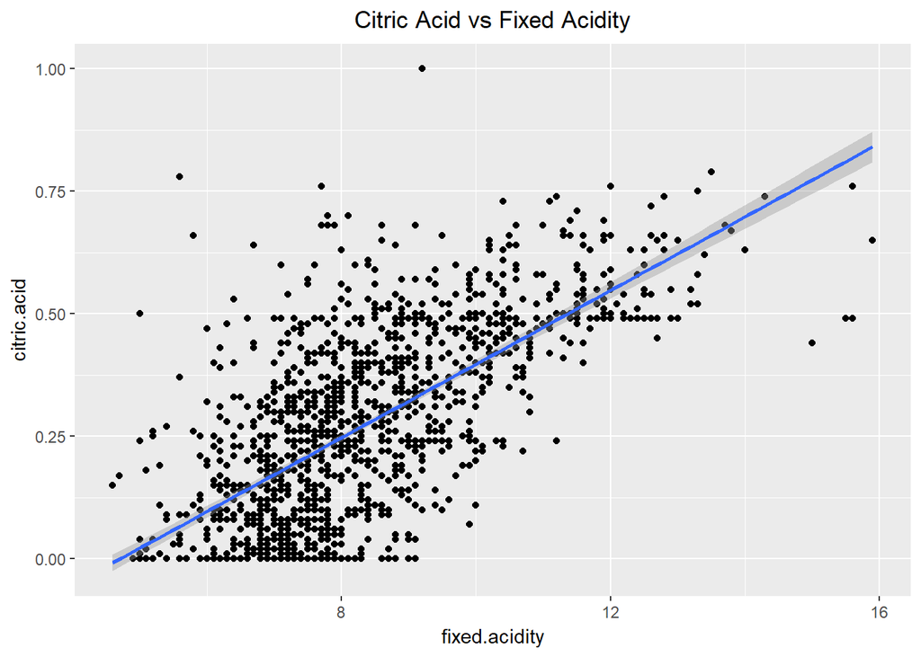

With a correaltion coefficient of about 0.7, as the amount of citric acid in the wine increase so does the amount of fixed acidity.

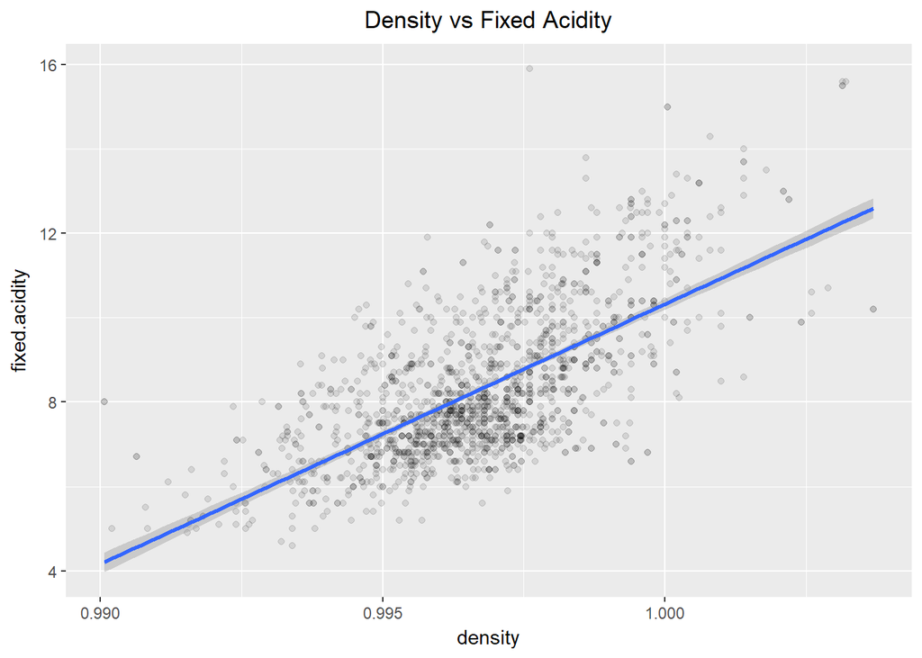

As fixed acidity increases so does censity. Fixed acidity are the acids that act as antioxidants which makes sense would increase the density of the wine as is prevents it from evaporating.

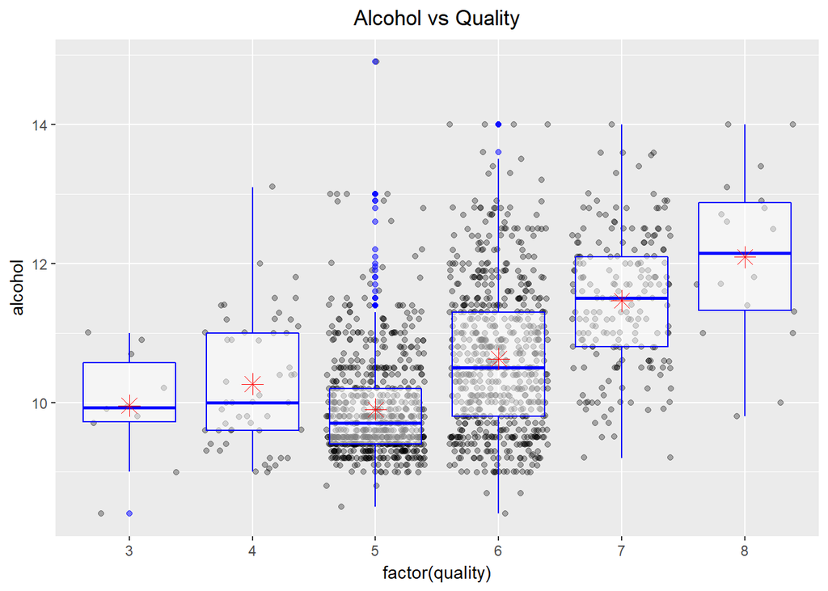

When it came to alcohol content, as it increased so do the quality of the wine. However, on the correlation diagram alcohol and quality do not appear to have a strong correaltion, this may be due to the fact that there were lest than 20 occurences of top quality wine out of 1600 observations.

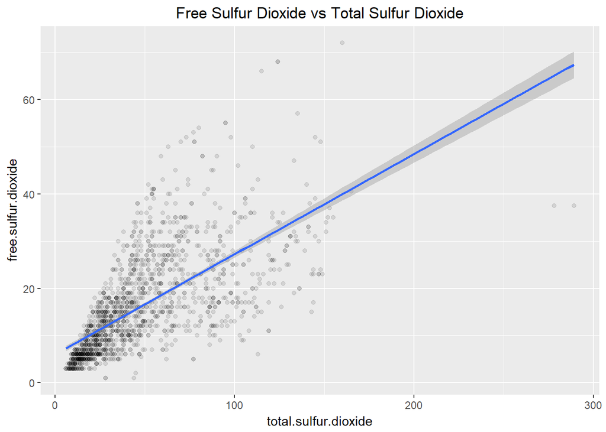

Lastly, free sulfur dioxide had a direct impact on total sulfur dioxide. No surpprise here as total sulfur dioxide is the sum of free form, free sulfur dioxide, and bound form SO2.

```
## # A tibble: 6 x 6
##   quality mean_alcohol median_alcohol min_alcohol max_alcohol     n
##     <int>        <dbl>          <dbl>       <dbl>       <dbl> <int>
## 1       3     9.955000          9.925         8.4        11.0    10
## 2       4    10.265094         10.000         9.0        13.1    53
## 3       5     9.899706          9.700         8.5        14.9   681
## 4       6    10.629519         10.500         8.4        14.0   638
## 5       7    11.465913         11.500         9.2        14.0   199
## 6       8    12.094444         12.150         9.8        14.0    18
```

# Bivariate Analysis

# Multivariate Plots Section

In this section I created multiple matrices and 3 variable scatterplots to represent the most prominent relationships in those matrices.

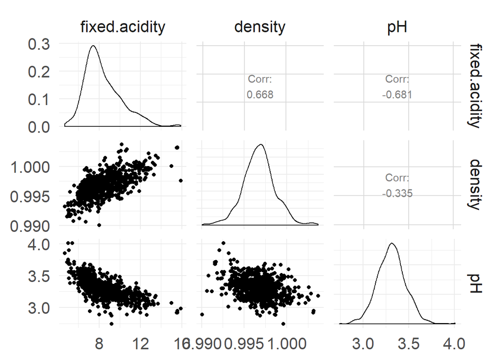

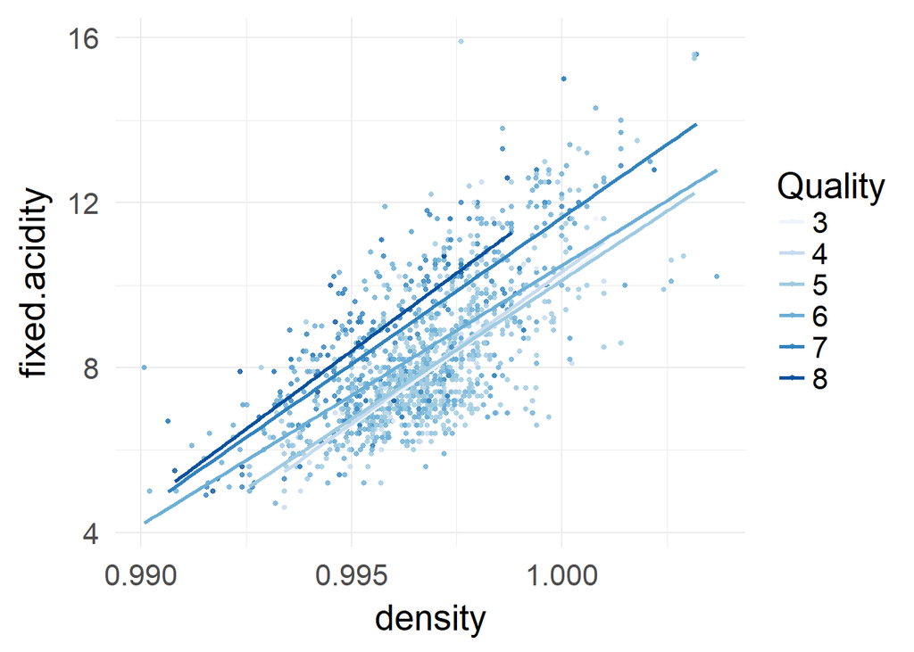

The matrix showed that density and fixed acidity had a correlation coefficient of 0.66 which is very strong. The scatterplot shows an somewhat even ditribution of density regardless of the quality of the wine but there is a high concentration of lower quality wines in lower fixed acidity level and the higher quality wines appear to have higher fixed acidity levels.

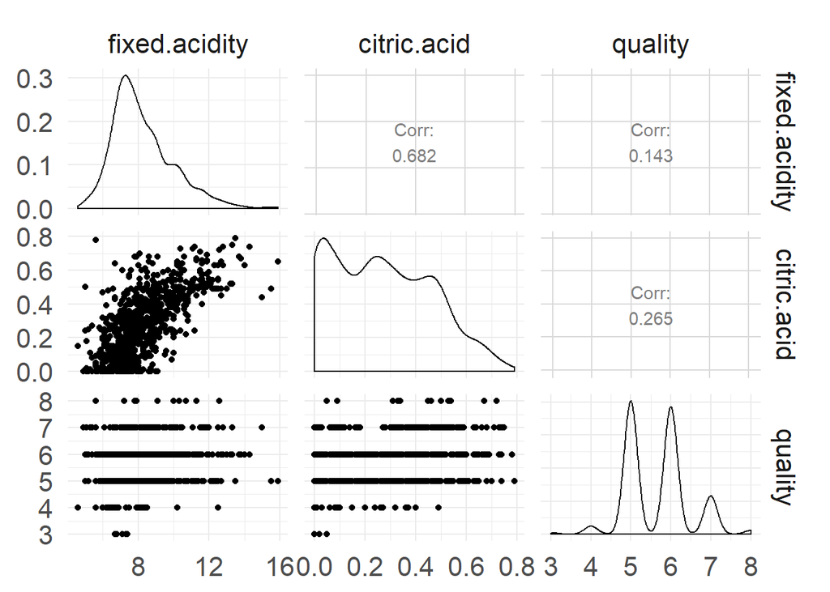

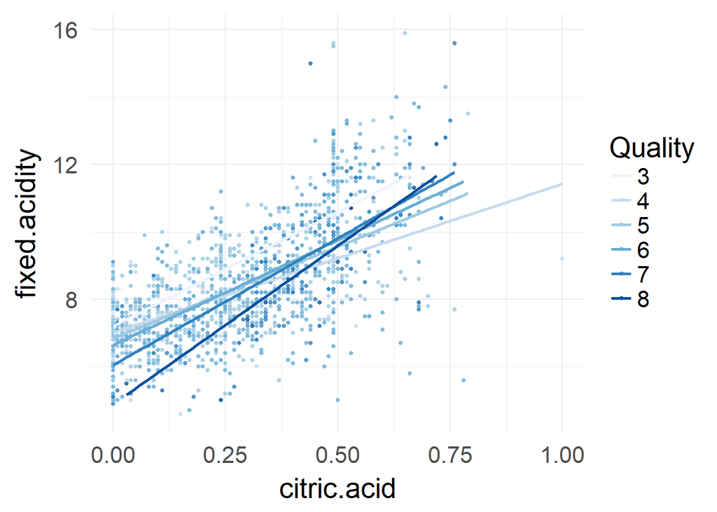

# Multivariate Analysis

- I observed the relationship between density and fixed acidity, and citrici acid and fixed acidity, and where qualty of the wine falls in both spectrum. I chose those relationships because the had the strongest correlations according to the matrices and i would to look deeper and better visualize those relationships. I noticed that higher quality wines had higher citric acid and fixed acidity levels. Whereas, lower quality wines had lower citric acid and fixed acidity levels. Also, density did not play much of a rolw in the quality of the wine.
- I would have thought the density woudld have a bigger impact on the quality of the wine, but given that wine density does not have a wide range, none of the wines were drastically different in that regard.

# Final Plots and Summary

**Plot One:**

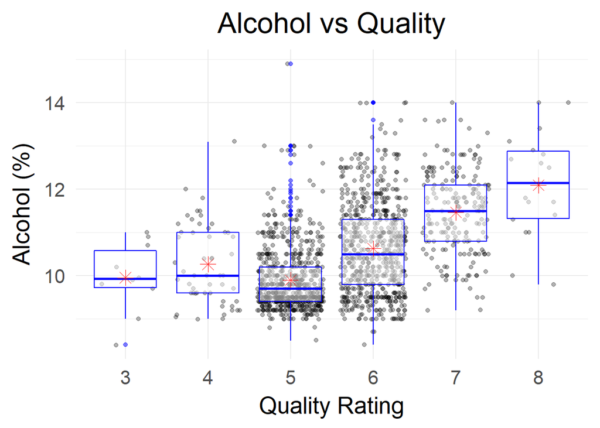

**Description One:**

I chose this plot and statistical output to show the relationship of alcohol content and wine quality. The correlation plot did not demonstrate such a strong relationship but after further investigating and taking into account to fact that there were only about 20 instances of high quality wine out of 1600 oberservations which would have skewed the data, I found an evident correlation betwen the variables. The top quality wine had a maximum of 14% alcohol content and a mean of 12.1%, while the lowest quality wine had a maximum of 11% alcohol content and a mean of 9.9%.

**Plot Two:**

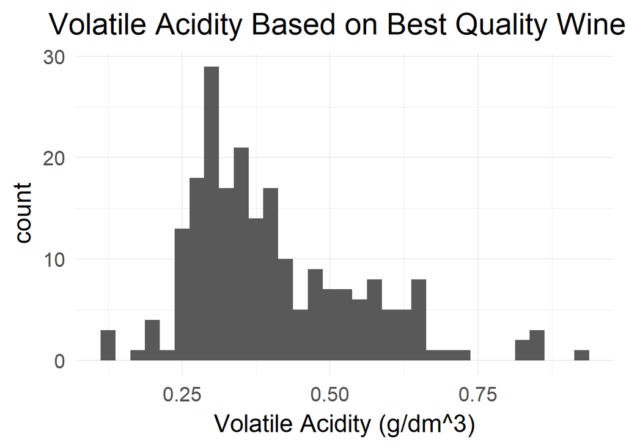

**Description Two:**

The overall max for volatile acidity is 1.6 and the minimum is 0.12. The lower volatile acidity levels were associated with better quality wine. THe max level for the best quality wines was 0.9 with a median of 0.37 and its minimum was equal to the minimum of the entire dataset.

**Plot Three:**

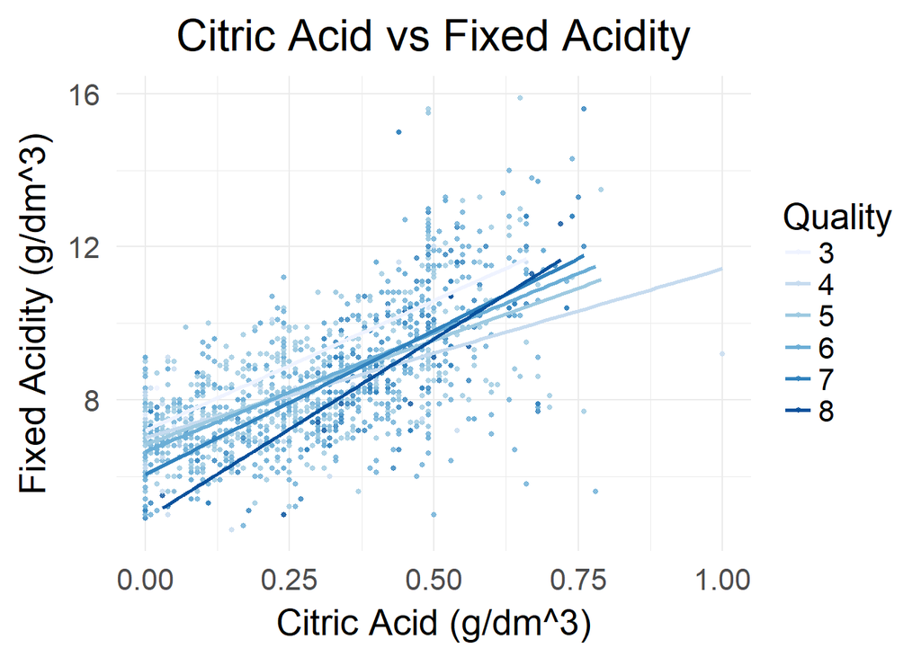

# Reflection

The red wine data set contained a totoal of 1599 observations and 11 variables. I statred by exploring the indvidual variable to get a better understanding of their ditribution and investigating how each chemical property affects the wine. Some affects the taste, while others serve as antioxidants and antimicrobials. I found that the volatile acidity was one of the properties that had direct impact on the flavor of the wine and so I decide to examine the property based on best quality and worst quality wines. I found that the best quality wines had significantly lower levels of volatile acidity.

There was some difficuly determining which properties had any relationship to other variable or not and which ones had any significant impact of the wine. Therefore, I ran a correlation plot to get a better picture of the different relationships between the variables. I found a number of different pairs with strong relationships suh as citric acid and fixed acidity, density and fixed acidity, alcohol and quality, and free sulfur dioxide and total sulfur dioxide. For each pair, as one increase so did the other. Better wines had higher levels of citric acid, fixed acidity, and alcohol. Density did not have much of an impact on the quality of the wine.

I then took it one step further to get an even better visualtizations of these relationships by creating 3 variable scatterplots. This helped visualize the spread of the quality of the wines amongst the different vairables. Overall, I found that there were 4 main chemical properties that really influenced the quality of the wine, mainly affecting the flavor and those were: volatile acidity, citric acid, fixed acidity, and alcohol. It was interesting to analyze a set of data without knowing anything about the topic and being able to extract some meaningful insights. Overall, I think it was a success.